# Praca domowa 2

Jakub Niemyjski

2023-03-18

## Źródło

W ramach pracy domowej 2 zdecydowałem się na wybór poprawy wykresu z następującego źródła: https://twitter.com/marcfbellemare/status/1635704208254017536.

Prezentuje się on w ten sposób:

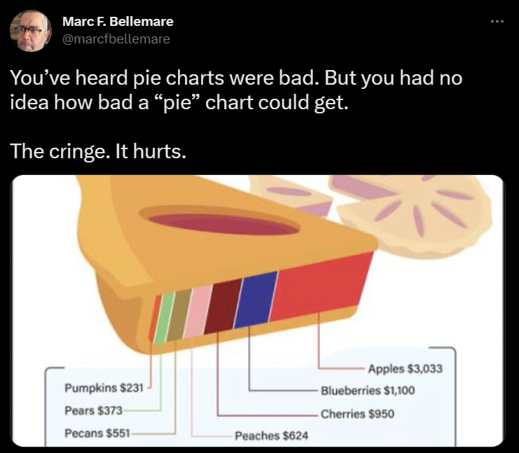

```r
knitr::include_graphics("zrodlo.png")
```

## Poprawa wykresu

Wprowadźmy dane ze znalezionego wykresu do programu i stwórzmy na ich podstawie ramkę danych o nazwie `ceny_owocow`.

```r
owoce <- c("dynie", "gruszki", "pekany", "brzoskwinie", "wiśnie", "jagody", "jabłka")
kwota <- c(231, 373, 551, 624, 950, 1100, 3033)
ceny_owocow <- data.frame(owoce, kwota)
```

Szybkie jej podsumowanie:

```r
print(ceny_owocow)
```

```
##         owoce kwota
## 1       dynie   231
## 2     gruszki   373
## 3      pekany   551
## 4 brzoskwinie   624
## 5      wiśnie   950
## 6      jagody  1100
## 7      jabłka  3033
```

```r
summary(ceny_owocow)
```

```
##     owoce               kwota
##  Length:7           Min.   : 231.0
##  Class :character   1st Qu.: 462.0
##  Mode  :character   Median : 624.0
##                     Mean   : 980.3
##                     3rd Qu.:1025.0
##                     Max.   :3033.0
```

Z uwagi na brak kontekstu w źródle, nie można być pewnym czego konkretnie on dotyczy: czy cen owoców za określoną jednostkę masy, czy może łączną kwotę wydaną na te owoce przez dany czas, bądź jeszcze coś innego. Możliwości jest wiele.

Z tego powodu założę, że jest to skumulowana kwota przychodu w wyniku sprzedaży owoców przez pewnego sprzedawce w danym okresie.

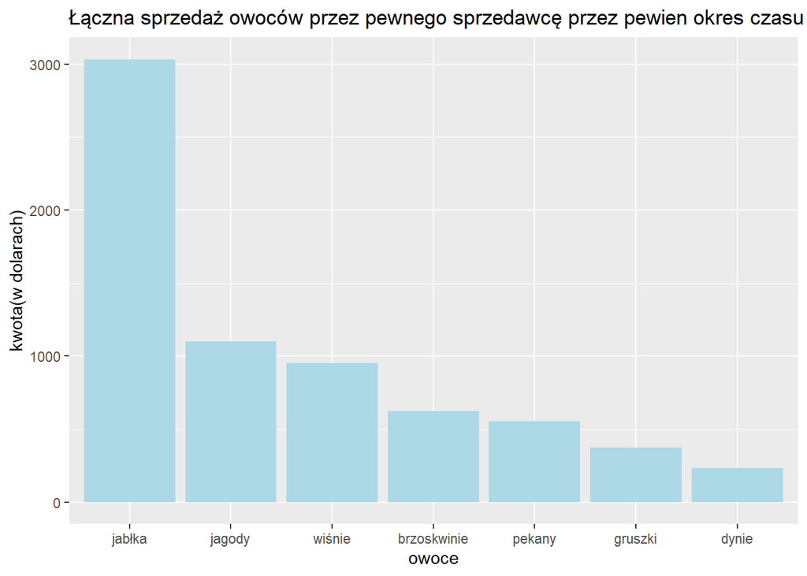

```r
ceny_owocow %>%
  mutate(fruits = forcats::fct_rev(forcats::fct_reorder(owoce, kwota))) %>%
  ggplot(aes(x=fruits, y=kwota)) +
  geom_col(fill="lightblue") +
  labs(title="Łączna sprzedaż owoców przez pewnego sprzedawcę przez pewien okres czasu ",
       x = "owoce",
       y = "kwota(w dolarach)")
```

## Uzasadnienie poprawy

Orginalny wykres jest nieodpowiedni. Po pierwsze jest wykresem w trójwymiarze, co czasem może prowadzić do nieścisłości w odczytywaniu wartości. Ponadto cały przedstawiony jest w pewnym poziomym pasku, co też nie pozwala bez zawahania stwierdzić, sprzedaż którego z owoców jest większa i ewentualnie o ile, w jakich proporcjach. Dlatego znacznie lepiej byłoby tu wykorzystać wykres w dwuwymiarze, oczywiście zaczynający oś ceny od zera, tak, aby był widoczny stosunek różnic w kwotach (ponieważ kwota to zmienna ilościowa ilorazowa). Drugi wykres ma również uszeregowanie od największej sprzedaży do największej, co też upraszcza wyciągniecie z wykresu pewnych wniosków.